# From the command line: rmarkdown::render(‘FLAIRR.Rmd’, params=list(data=“../processed_samples/1001-667/results/reports”, sample=“1001-667”))

# Summary of Final Output

Final processed output is contained in the `total`, `unique`, and `unique-atleast-2` files, which contain all processed sequences, unique sequences, and only those unique sequences represented by at least two raw reads, respectively. The figures below shown the distributions of annotations for these final output files.

## Distribution of read and UMI counts

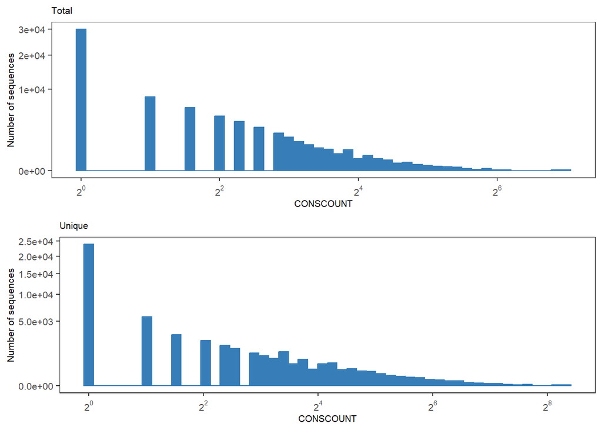

Figure 7: Histogram showing the distribution of read counts (CONSCOUNT) for total sequences (top) and unique sequences (bottom).

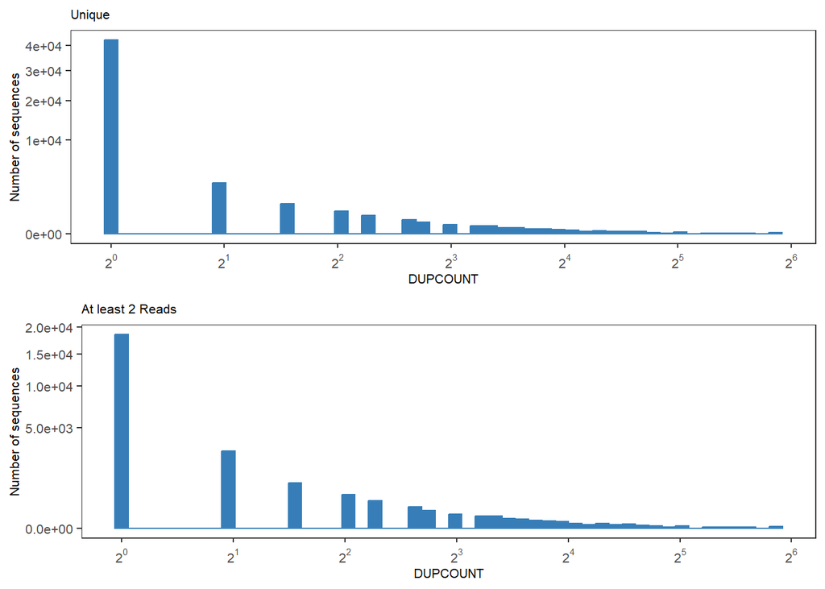

Figure 8: Histogram showing the distribution of unique UMI counts for all unique sequences (top) and unique sequences represented by at least two raw reads (bottom).

## C-region annotations

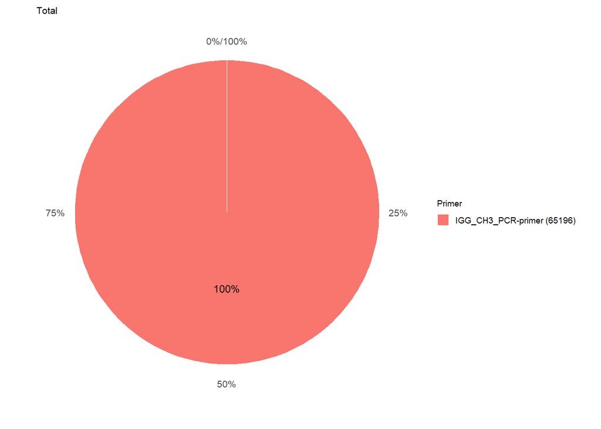

Figure 9: Percentage internal C-region annotations for total sequences. Parenthetical numbers in the legend are the number of sequences.

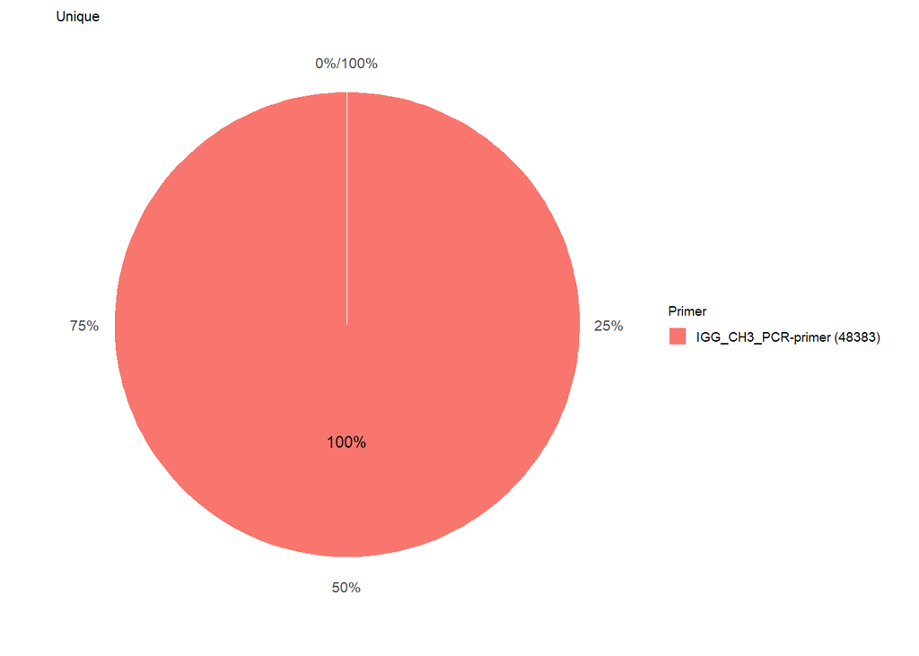

Figure 10: Percentage internal C-region annotations for all unique sequences. Parenthetical numbers in the legend are the number of sequences.

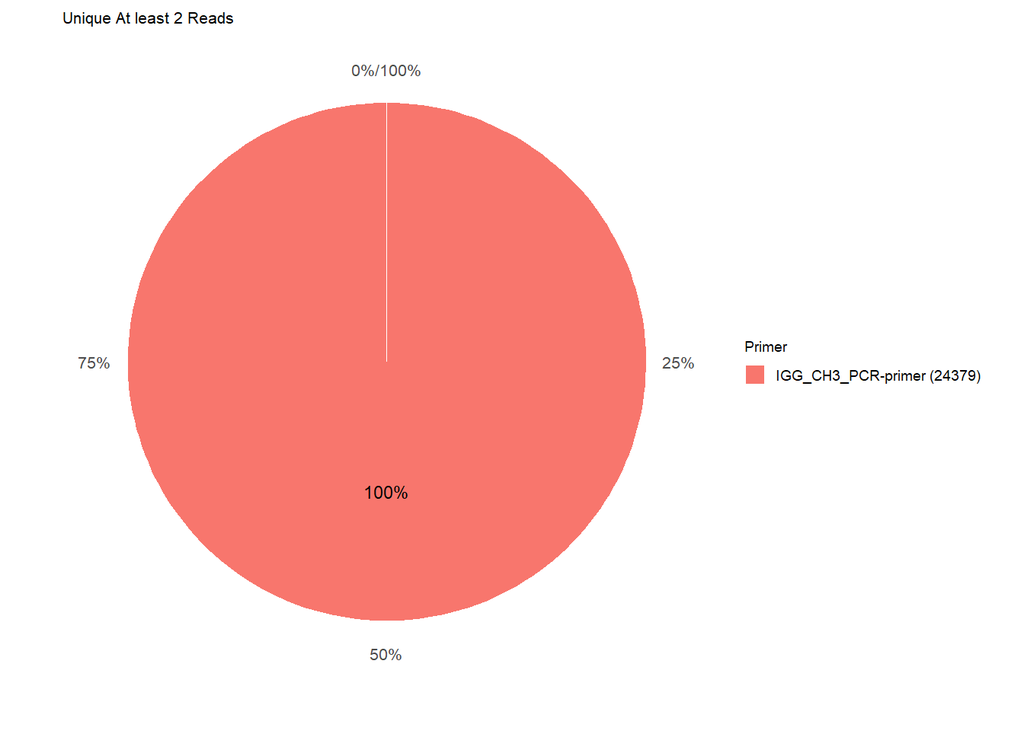

Figure 11: Percentage internal C-region annotations for unique sequences represented by at least two raw reads. Parenthetical numbers in the legend are the number of sequences.